[figure not shown]

# Term 1 Project EDA

### 1. Problem Statement

EDA ia a critical and first step in analyzing the data:

Objectives

```
- Know the data types of the dataset
- Understand how the data is distributed
- Extract important input variables for the analysis
- Checking of assumptions
- Identify outliers and missing data
- To identity patterns, if exists
```

### 2. Data Loading and Description

[figure not shown]

| Column Name | Description |
| --- | --- |
| Year | Year of Oylmpic Event |
| City | City where Oylmpic Event held |
| Sport | Type of Sport |
| Discipline | Discipline of Sport |
| Athlete | Name of the Athlete (Last Name followed by First Name) |
| Country | Country from where Athlete belongs |
| Gender | Gender of the Athlete |
| Event | Sports Event Type |
| Medal | Type of Medal Won (Gold,Silver,Bronze) |

# Some Background Information

The creation was inspired by the ancient **Olympic Games**, which were held in **Olympia, Greece,** from the 8th century BC to the 4th century AD. Baron Pierre de Coubertin founded the International Olympic Committee (IOC) in 1894, leading to the first modern Games in Athens in 1896.

The modern Olympic Games or Olympics are leading international sporting events featuring summer and winter sports competitions in which thousands of athletes from around the world participate in a variety of competitions. The Olympic Games are considered the world's foremost sports competition with more than 200 nations participating.The Olympic Games are held every **four years**, with the Summer and Winter Games alternating by occurring every four years but two years apart

#### Importing packages

```python
import sys       # Check the modules and packages availble in Anaconda to perform the Pandas and numpy operations
sys.path
```

[output not shown]

**Note** If the packages is missing you need to install the package from Anaconda Prompt use statement **pip install package-name**"

```python
import numpy as np                                                 # Implemennts milti-dimensional array and matrices
import pandas as pd                                                # For data manipulation and analysis
import pandas_profiling
import matplotlib.pyplot as plt                                    # Plotting library for Python programming language and it's numerical mathematics extension NumPy
import seaborn as sns                                              # Provides a high level interface for drawing attractive and informative statistical graphics
%matplotlib inline
sns.set()

from subprocess import check_output
```

#### Importing the Dataset

```python
olympics_data = pd.read_csv("https://raw.githubusercontent.com/swap002/EDA/master/olympics_data.csv",encoding='iso-8859-1')     # Importing training dataset using pd.read_csv
```

```python
olympics_data
```

|  | Year | City | Sport | Discipline | Athlete | Country | Gender | Event | Medal |
| --- | --- | --- | --- | --- | --- | --- | --- | --- | --- |
| 0 | 1896 | Athens | Aquatics | Swimming | HAJOS, Alfred | HUN | Men | 100M Freestyle | Gold |
| 1 | 1896 | Athens | Aquatics | Swimming | HERSCHMANN, Otto | AUT | Men | 100M Freestyle | Silver |
| 2 | 1896 | Athens | Aquatics | Swimming | DRIVAS, Dimitrios | GRE | Men | 100M Freestyle For Sailors | Bronze |
| 3 | 1896 | Athens | Aquatics | Swimming | MALOKINIS, Ioannis | GRE | Men | 100M Freestyle For Sailors | Gold |
| 4 | 1896 | Athens | Aquatics | Swimming | CHASAPIS, Spiridon | GRE | Men | 100M Freestyle For Sailors | Silver |
| 5 | 1896 | Athens | Aquatics | Swimming | CHOROPHAS, Efstathios | GRE | Men | 1200M Freestyle | Bronze |
| 6 | 1896 | Athens | Aquatics | Swimming | HAJOS, Alfred | HUN | Men | 1200M Freestyle | Gold |
| 7 | 1896 | Athens | Aquatics | Swimming | ANDREOU, Joannis | GRE | Men | 1200M Freestyle | Silver |
| 8 | 1896 | Athens | Aquatics | Swimming | CHOROPHAS, Efstathios | GRE | Men | 400M Freestyle | Bronze |
| 9 | 1896 | Athens | Aquatics | Swimming | NEUMANN, Paul | AUT | Men | 400M Freestyle | Gold |
| 10 | 1896 | Athens | Aquatics | Swimming | PEPANOS, Antonios | GRE | Men | 400M Freestyle | Silver |
| 11 | 1896 | Athens | Athletics | Athletics | LANE, Francis | USA | Men | 100M | Bronze |
| 12 | 1896 | Athens | Athletics | Athletics | SZOKOLYI, Alajos | HUN | Men | 100M | Bronze |
| 13 | 1896 | Athens | Athletics | Athletics | BURKE, Thomas | USA | Men | 100M | Gold |
| 14 | 1896 | Athens | Athletics | Athletics | HOFMANN, Fritz | GER | Men | 100M | Silver |
| 15 | 1896 | Athens | Athletics | Athletics | CURTIS, Thomas | USA | Men | 110M Hurdles | Gold |
| 16 | 1896 | Athens | Athletics | Athletics | GOULDING, Grantley | GBR | Men | 110M Hurdles | Silver |
| 17 | 1896 | Athens | Athletics | Athletics | LERMUSIAUX, Albin | FRA | Men | 1500M | Bronze |
| 18 | 1896 | Athens | Athletics | Athletics | FLACK, Edwin | AUS | Men | 1500M | Gold |
| 19 | 1896 | Athens | Athletics | Athletics | BLAKE, Arthur | USA | Men | 1500M | Silver |
| 20 | 1896 | Athens | Athletics | Athletics | GMELIN, Charles | GBR | Men | 400M | Bronze |
| 21 | 1896 | Athens | Athletics | Athletics | BURKE, Thomas | USA | Men | 400M | Gold |
| 22 | 1896 | Athens | Athletics | Athletics | JAMISON, Herbert | USA | Men | 400M | Silver |
| 23 | 1896 | Athens | Athletics | Athletics | GOLEMIS, Dimitrios | GRE | Men | 800M | Bronze |
| 24 | 1896 | Athens | Athletics | Athletics | FLACK, Edwin | AUS | Men | 800M | Gold |
| 25 | 1896 | Athens | Athletics | Athletics | DANI, Nandor | HUN | Men | 800M | Silver |
| 26 | 1896 | Athens | Athletics | Athletics | VERSIS, Sotirios | GRE | Men | Discus Throw | Bronze |
| 27 | 1896 | Athens | Athletics | Athletics | GARRETT, Robert | USA | Men | Discus Throw | Gold |
| 28 | 1896 | Athens | Athletics | Athletics | PARASKEVOPOULOS, Panagiotis | GRE | Men | Discus Throw | Silver |
| 29 | 1896 | Athens | Athletics | Athletics | CLARK, Ellery | USA | Men | High Jump | Gold |
| ... | ... | ... | ... | ... | ... | ... | ... | ... | ... |
| 31135 | 2012 | London | Wrestling | Wrestling Freestyle | GAZYUMOV, Khetag | AZE | Men | Wf 96 KG | Bronze |
| 31136 | 2012 | London | Wrestling | Wrestling Freestyle | GOGSHELIDZE, George | GEO | Men | Wf 96 KG | Bronze |
| 31137 | 2012 | London | Wrestling | Wrestling Freestyle | LOPEZ NUNEZ, Mijain | CUB | Men | Wg 120 KG | Gold |
| 31138 | 2012 | London | Wrestling | Wrestling Freestyle | NABI, Heiki | EST | Men | Wg 120 KG | Silver |
| 31139 | 2012 | London | Wrestling | Wrestling Freestyle | EUREN, Johan | SWE | Men | Wg 120 KG | Bronze |
| 31140 | 2012 | London | Wrestling | Wrestling Freestyle | KAYAALP, Riza | TUR | Men | Wg 120 KG | Bronze |
| 31141 | 2012 | London | Wrestling | Wrestling Freestyle | SORYAN REIHANPOUR, Hamid Mohammad | IRI | Men | Wg 55 KG | Gold |
| 31142 | 2012 | London | Wrestling | Wrestling Freestyle | BAYRAMOV, Rovshan | AZE | Men | Wg 55 KG | Silver |
| 31143 | 2012 | London | Wrestling | Wrestling Freestyle | MODOS, Peter | HUN | Men | Wg 55 KG | Bronze |
| 31144 | 2012 | London | Wrestling | Wrestling Freestyle | SEMENOV, Mingiyan | RUS | Men | Wg 55 KG | Bronze |
| 31145 | 2012 | London | Wrestling | Wrestling Freestyle | NOROOZI, Omid Haji | IRI | Men | Wg 60 KG | Gold |
| 31146 | 2012 | London | Wrestling | Wrestling Freestyle | LASHKHI, Revaz | GEO | Men | Wg 60 KG | Silver |
| 31147 | 2012 | London | Wrestling | Wrestling Freestyle | KURAMAGOMEDOV, Zaur | RUS | Men | Wg 60 KG | Bronze |
| 31148 | 2012 | London | Wrestling | Wrestling Freestyle | MATSUMOTO, Ryutaro | JPN | Men | Wg 60 KG | Bronze |
| 31149 | 2012 | London | Wrestling | Wrestling Freestyle | KIM, Hyeonwoo | KOR | Men | Wg 66 KG | Gold |
| 31150 | 2012 | London | Wrestling | Wrestling Freestyle | LORINCZ, Tamas | HUN | Men | Wg 66 KG | Silver |
| 31151 | 2012 | London | Wrestling | Wrestling Freestyle | GUENOT, Steeve | FRA | Men | Wg 66 KG | Bronze |
| 31152 | 2012 | London | Wrestling | Wrestling Freestyle | TSKHADAIA, Manuchar | GEO | Men | Wg 66 KG | Bronze |
| 31153 | 2012 | London | Wrestling | Wrestling Freestyle | VLASOV, Roman | RUS | Men | Wg 74 KG | Gold |
| 31154 | 2012 | London | Wrestling | Wrestling Freestyle | JULFALAKYAN, Arsen | ARM | Men | Wg 74 KG | Silver |
| 31155 | 2012 | London | Wrestling | Wrestling Freestyle | AHMADOV, Emin | AZE | Men | Wg 74 KG | Bronze |
| 31156 | 2012 | London | Wrestling | Wrestling Freestyle | KAZAKEVIC, Aleksandr | LTU | Men | Wg 74 KG | Bronze |
| 31157 | 2012 | London | Wrestling | Wrestling Freestyle | KHUGAEV, Alan | RUS | Men | Wg 84 KG | Gold |
| 31158 | 2012 | London | Wrestling | Wrestling Freestyle | EBRAHIM, Karam Mohamed Gaber | EGY | Men | Wg 84 KG | Silver |
| 31159 | 2012 | London | Wrestling | Wrestling Freestyle | GAJIYEV, Danyal | KAZ | Men | Wg 84 KG | Bronze |
| 31160 | 2012 | London | Wrestling | Wrestling Freestyle | JANIKOWSKI, Damian | POL | Men | Wg 84 KG | Bronze |
| 31161 | 2012 | London | Wrestling | Wrestling Freestyle | REZAEI, Ghasem Gholamreza | IRI | Men | Wg 96 KG | Gold |
| 31162 | 2012 | London | Wrestling | Wrestling Freestyle | TOTROV, Rustam | RUS | Men | Wg 96 KG | Silver |
| 31163 | 2012 | London | Wrestling | Wrestling Freestyle | ALEKSANYAN, Artur | ARM | Men | Wg 96 KG | Bronze |
| 31164 | 2012 | London | Wrestling | Wrestling Freestyle | LIDBERG, Jimmy | SWE | Men | Wg 96 KG | Bronze |

31165 rows × 9 columns

Note: "Must supply the encoding='iso-8859-1' ,otherwise you will get error Error tokenizing data. C error: Expected 2 fields in line 3, saw 12"

Skipped data due to error in data file while reading csv file using option "error_bad_lines=False" is not recommended as it will remove important details from the file.

## 3. Data Profiling

### 3.1 Understanding the Dataset

To gain insights from data we must look into each aspect of it very carefully. We will start with observing few rows and columns of data both from the starting and from the end

```python
olympics_data.shape                                                   # This will print the number of rows and comlumns of the Data Frame
```

```
(31165, 9)
```

olympics_data has **31165 rows** and **9 columns.**

```python
olympics_data.columns                                          # This will print the names of all columns.
```

```
Index(['Year', 'City', 'Sport', 'Discipline', 'Athlete', 'Country', 'Gender',
       'Event', 'Medal'],
      dtype='object')
```

```python
olympics_data.head()
```

|  | Year | City | Sport | Discipline | Athlete | Country | Gender | Event | Medal |
| --- | --- | --- | --- | --- | --- | --- | --- | --- | --- |
| 0 | 1896 | Athens | Aquatics | Swimming | HAJOS, Alfred | HUN | Men | 100M Freestyle | Gold |
| 1 | 1896 | Athens | Aquatics | Swimming | HERSCHMANN, Otto | AUT | Men | 100M Freestyle | Silver |
| 2 | 1896 | Athens | Aquatics | Swimming | DRIVAS, Dimitrios | GRE | Men | 100M Freestyle For Sailors | Bronze |
| 3 | 1896 | Athens | Aquatics | Swimming | MALOKINIS, Ioannis | GRE | Men | 100M Freestyle For Sailors | Gold |
| 4 | 1896 | Athens | Aquatics | Swimming | CHASAPIS, Spiridon | GRE | Men | 100M Freestyle For Sailors | Silver |

```python
olympics_data.tail()                                                   # This will print the last n rows of the Data Frame
```

|  | Year | City | Sport | Discipline | Athlete | Country | Gender | Event | Medal |
| --- | --- | --- | --- | --- | --- | --- | --- | --- | --- |
| 31160 | 2012 | London | Wrestling | Wrestling Freestyle | JANIKOWSKI, Damian | POL | Men | Wg 84 KG | Bronze |
| 31161 | 2012 | London | Wrestling | Wrestling Freestyle | REZAEI, Ghasem Gholamreza | IRI | Men | Wg 96 KG | Gold |
| 31162 | 2012 | London | Wrestling | Wrestling Freestyle | TOTROV, Rustam | RUS | Men | Wg 96 KG | Silver |
| 31163 | 2012 | London | Wrestling | Wrestling Freestyle | ALEKSANYAN, Artur | ARM | Men | Wg 96 KG | Bronze |
| 31164 | 2012 | London | Wrestling | Wrestling Freestyle | LIDBERG, Jimmy | SWE | Men | Wg 96 KG | Bronze |

```python
olympics_data.info()                                                   # This will give Index, Datatype and Memory information
```

```
<class 'pandas.core.frame.DataFrame'>
RangeIndex: 31165 entries, 0 to 31164
Data columns (total 9 columns):
Year          31165 non-null int64
City          31165 non-null object
Sport         31165 non-null object
Discipline    31165 non-null object
Athlete       31165 non-null object
Country       31161 non-null object
Gender        31165 non-null object
Event         31165 non-null object
Medal         31165 non-null object
dtypes: int64(1), object(8)
memory usage: 2.1+ MB
```

```python
olympics_data.describe()
```

|  | Year |
| --- | --- |
| count | 31165.000000 |
| mean | 1970.482785 |
| std | 33.158416 |
| min | 1896.000000 |
| 25% | 1948.000000 |
| 50% | 1980.000000 |
| 75% | 2000.000000 |
| max | 2012.000000 |

```python
olympics_data.isnull().sum()
```

```
Year          0
City          0
Sport         0
Discipline    0
Athlete       0
Country       4
Gender        0
Event         0
Medal         0
dtype: int64
```

### 3.2 Pre Profiling

- By pandas profiling, an **interactive HTML report** gets generated which contins all the information about the columns of the dataset, like the **counts and type** of each *column*. Detailed information about each column, **coorelation between different columns** and a sample of dataset.
- It gives us **visual interpretation** of each column in the data.
- *Spread of the data* can be better understood by the distribution plot.
- *Detailed* analysis of each column.

```python
profile = pandas_profiling.ProfileReport(olympics_data)
profile.to_file(outputfile="summer_olympics_before_preprocessing.html")
```

Here, we have done Pandas Profiling before preprocessing our dataset, so we have named the html file as **summer_olympics_before_preprocessing.html**. Take a look at the file and see what useful insight you can develop from it.  
Now we will process our data to better understand it.

### 3.3 Preprocessing

**Dataset info**

```
- Number of variables   9
- Number of observations    31165
- Total Missing (%)     0.0%
- Total size in memory  2.1 MiB
- Average record size in memory     72.0 B
```

**Variables types**

```
- Numeric   1
- Categorical   8
- Boolean   0
- Date  0
- Text (Unique)     0
- Rejected  0
- Unsupported   0
```

### 4. Questions

### 4.1 Top 10 countries and Bottom 10 countries ?

#### Top 10 countries.

```python
olympics_data_clean = olympics_data  # This will make a copy of the main Data Frame
```

```python
olympics_data_clean.drop_duplicates() # This will remove the duplicate from copy of main Data Frame
```

|  | Year | City | Sport | Discipline | Athlete | Country | Gender | Event | Medal |
| --- | --- | --- | --- | --- | --- | --- | --- | --- | --- |
| 0 | 1896 | Athens | Aquatics | Swimming | HAJOS, Alfred | HUN | Men | 100M Freestyle | Gold |
| 1 | 1896 | Athens | Aquatics | Swimming | HERSCHMANN, Otto | AUT | Men | 100M Freestyle | Silver |
| 2 | 1896 | Athens | Aquatics | Swimming | DRIVAS, Dimitrios | GRE | Men | 100M Freestyle For Sailors | Bronze |
| 3 | 1896 | Athens | Aquatics | Swimming | MALOKINIS, Ioannis | GRE | Men | 100M Freestyle For Sailors | Gold |
| 4 | 1896 | Athens | Aquatics | Swimming | CHASAPIS, Spiridon | GRE | Men | 100M Freestyle For Sailors | Silver |
| 5 | 1896 | Athens | Aquatics | Swimming | CHOROPHAS, Efstathios | GRE | Men | 1200M Freestyle | Bronze |
| 6 | 1896 | Athens | Aquatics | Swimming | HAJOS, Alfred | HUN | Men | 1200M Freestyle | Gold |
| 7 | 1896 | Athens | Aquatics | Swimming | ANDREOU, Joannis | GRE | Men | 1200M Freestyle | Silver |
| 8 | 1896 | Athens | Aquatics | Swimming | CHOROPHAS, Efstathios | GRE | Men | 400M Freestyle | Bronze |
| 9 | 1896 | Athens | Aquatics | Swimming | NEUMANN, Paul | AUT | Men | 400M Freestyle | Gold |
| 10 | 1896 | Athens | Aquatics | Swimming | PEPANOS, Antonios | GRE | Men | 400M Freestyle | Silver |
| 11 | 1896 | Athens | Athletics | Athletics | LANE, Francis | USA | Men | 100M | Bronze |
| 12 | 1896 | Athens | Athletics | Athletics | SZOKOLYI, Alajos | HUN | Men | 100M | Bronze |
| 13 | 1896 | Athens | Athletics | Athletics | BURKE, Thomas | USA | Men | 100M | Gold |
| 14 | 1896 | Athens | Athletics | Athletics | HOFMANN, Fritz | GER | Men | 100M | Silver |
| 15 | 1896 | Athens | Athletics | Athletics | CURTIS, Thomas | USA | Men | 110M Hurdles | Gold |
| 16 | 1896 | Athens | Athletics | Athletics | GOULDING, Grantley | GBR | Men | 110M Hurdles | Silver |
| 17 | 1896 | Athens | Athletics | Athletics | LERMUSIAUX, Albin | FRA | Men | 1500M | Bronze |
| 18 | 1896 | Athens | Athletics | Athletics | FLACK, Edwin | AUS | Men | 1500M | Gold |
| 19 | 1896 | Athens | Athletics | Athletics | BLAKE, Arthur | USA | Men | 1500M | Silver |
| 20 | 1896 | Athens | Athletics | Athletics | GMELIN, Charles | GBR | Men | 400M | Bronze |
| 21 | 1896 | Athens | Athletics | Athletics | BURKE, Thomas | USA | Men | 400M | Gold |
| 22 | 1896 | Athens | Athletics | Athletics | JAMISON, Herbert | USA | Men | 400M | Silver |
| 23 | 1896 | Athens | Athletics | Athletics | GOLEMIS, Dimitrios | GRE | Men | 800M | Bronze |
| 24 | 1896 | Athens | Athletics | Athletics | FLACK, Edwin | AUS | Men | 800M | Gold |
| 25 | 1896 | Athens | Athletics | Athletics | DANI, Nandor | HUN | Men | 800M | Silver |
| 26 | 1896 | Athens | Athletics | Athletics | VERSIS, Sotirios | GRE | Men | Discus Throw | Bronze |
| 27 | 1896 | Athens | Athletics | Athletics | GARRETT, Robert | USA | Men | Discus Throw | Gold |
| 28 | 1896 | Athens | Athletics | Athletics | PARASKEVOPOULOS, Panagiotis | GRE | Men | Discus Throw | Silver |
| 29 | 1896 | Athens | Athletics | Athletics | CLARK, Ellery | USA | Men | High Jump | Gold |
| ... | ... | ... | ... | ... | ... | ... | ... | ... | ... |
| 31135 | 2012 | London | Wrestling | Wrestling Freestyle | GAZYUMOV, Khetag | AZE | Men | Wf 96 KG | Bronze |
| 31136 | 2012 | London | Wrestling | Wrestling Freestyle | GOGSHELIDZE, George | GEO | Men | Wf 96 KG | Bronze |
| 31137 | 2012 | London | Wrestling | Wrestling Freestyle | LOPEZ NUNEZ, Mijain | CUB | Men | Wg 120 KG | Gold |
| 31138 | 2012 | London | Wrestling | Wrestling Freestyle | NABI, Heiki | EST | Men | Wg 120 KG | Silver |
| 31139 | 2012 | London | Wrestling | Wrestling Freestyle | EUREN, Johan | SWE | Men | Wg 120 KG | Bronze |
| 31140 | 2012 | London | Wrestling | Wrestling Freestyle | KAYAALP, Riza | TUR | Men | Wg 120 KG | Bronze |
| 31141 | 2012 | London | Wrestling | Wrestling Freestyle | SORYAN REIHANPOUR, Hamid Mohammad | IRI | Men | Wg 55 KG | Gold |
| 31142 | 2012 | London | Wrestling | Wrestling Freestyle | BAYRAMOV, Rovshan | AZE | Men | Wg 55 KG | Silver |
| 31143 | 2012 | London | Wrestling | Wrestling Freestyle | MODOS, Peter | HUN | Men | Wg 55 KG | Bronze |
| 31144 | 2012 | London | Wrestling | Wrestling Freestyle | SEMENOV, Mingiyan | RUS | Men | Wg 55 KG | Bronze |
| 31145 | 2012 | London | Wrestling | Wrestling Freestyle | NOROOZI, Omid Haji | IRI | Men | Wg 60 KG | Gold |
| 31146 | 2012 | London | Wrestling | Wrestling Freestyle | LASHKHI, Revaz | GEO | Men | Wg 60 KG | Silver |
| 31147 | 2012 | London | Wrestling | Wrestling Freestyle | KURAMAGOMEDOV, Zaur | RUS | Men | Wg 60 KG | Bronze |
| 31148 | 2012 | London | Wrestling | Wrestling Freestyle | MATSUMOTO, Ryutaro | JPN | Men | Wg 60 KG | Bronze |
| 31149 | 2012 | London | Wrestling | Wrestling Freestyle | KIM, Hyeonwoo | KOR | Men | Wg 66 KG | Gold |
| 31150 | 2012 | London | Wrestling | Wrestling Freestyle | LORINCZ, Tamas | HUN | Men | Wg 66 KG | Silver |
| 31151 | 2012 | London | Wrestling | Wrestling Freestyle | GUENOT, Steeve | FRA | Men | Wg 66 KG | Bronze |
| 31152 | 2012 | London | Wrestling | Wrestling Freestyle | TSKHADAIA, Manuchar | GEO | Men | Wg 66 KG | Bronze |
| 31153 | 2012 | London | Wrestling | Wrestling Freestyle | VLASOV, Roman | RUS | Men | Wg 74 KG | Gold |
| 31154 | 2012 | London | Wrestling | Wrestling Freestyle | JULFALAKYAN, Arsen | ARM | Men | Wg 74 KG | Silver |
| 31155 | 2012 | London | Wrestling | Wrestling Freestyle | AHMADOV, Emin | AZE | Men | Wg 74 KG | Bronze |
| 31156 | 2012 | London | Wrestling | Wrestling Freestyle | KAZAKEVIC, Aleksandr | LTU | Men | Wg 74 KG | Bronze |
| 31157 | 2012 | London | Wrestling | Wrestling Freestyle | KHUGAEV, Alan | RUS | Men | Wg 84 KG | Gold |
| 31158 | 2012 | London | Wrestling | Wrestling Freestyle | EBRAHIM, Karam Mohamed Gaber | EGY | Men | Wg 84 KG | Silver |
| 31159 | 2012 | London | Wrestling | Wrestling Freestyle | GAJIYEV, Danyal | KAZ | Men | Wg 84 KG | Bronze |
| 31160 | 2012 | London | Wrestling | Wrestling Freestyle | JANIKOWSKI, Damian | POL | Men | Wg 84 KG | Bronze |
| 31161 | 2012 | London | Wrestling | Wrestling Freestyle | REZAEI, Ghasem Gholamreza | IRI | Men | Wg 96 KG | Gold |
| 31162 | 2012 | London | Wrestling | Wrestling Freestyle | TOTROV, Rustam | RUS | Men | Wg 96 KG | Silver |
| 31163 | 2012 | London | Wrestling | Wrestling Freestyle | ALEKSANYAN, Artur | ARM | Men | Wg 96 KG | Bronze |
| 31164 | 2012 | London | Wrestling | Wrestling Freestyle | LIDBERG, Jimmy | SWE | Men | Wg 96 KG | Bronze |

31163 rows × 9 columns

```python
topcountries = olympics_data_clean.Country.value_counts().head(10)
```

```python
values = topcountries.values
values
```

```
array([4585, 2049, 1720, 1396, 1305, 1296, 1189, 1079, 1044,  851],
      dtype=int64)
```

```python
countrynames = topcountries.keys()
countrynames
```

```
Index(['USA', 'URS', 'GBR', 'FRA', 'GER', 'ITA', 'AUS', 'HUN', 'SWE', 'NED'], dtype='object')
```

```python
# Get this figure: fig = py.get_figure("https://plot.ly/~swap002/0/")
# Get this figure's data: data = py.get_figure("https://plot.ly/~swap002/0/").get_data()
# Add data to this figure: py.plot(Data([Scatter(x=[1, 2], y=[2, 3])]), filename ="plot from API", fileopt="extend")
# Get y data of first trace: y1 = py.get_figure("https://plot.ly/~swap002/0/").get_data()[0]["y"]

# Get figure documentation: https://plot.ly/python/get-requests/
# Add data documentation: https://plot.ly/python/file-options/

# If you're using unicode in your file, you may need to specify the encoding.
# You can reproduce this figure in Python with the following code!

# Learn about API authentication here: https://plot.ly/python/getting-started
# Find your api_key here: https://plot.ly/settings/api

import plotly.plotly as py
from plotly.graph_objs import *
py.sign_in('swap002', 'K68OHkDOF3GSPCKHO3Dl') # API KEYS To ACCES
trace1 = {
  "x": countrynames,
  "y": values,
  "name": "x",
  "type": "bar",
  "uid": "4c082864-cac6-11e8-8ec5-645a049df699",
  "xsrc": "swap002:1:3ba77f",
  "ysrc": "swap002:1:5e10ce"
}
data = Data([trace1])
layout = {
  "title": "Top 10 Countries by Medal Won)",
  "xaxis": {
    "autorange": True,
    "range": [-0.5, 6.5],
    "title": "x",
    "type": "category"
  },
  "yaxis": {
    "autorange": True,
    "range": [0, 27.3684210526],
    "title": "y",
    "type": "linear"
  }
}
fig = Figure(data=data, layout=layout)
plot_url = py.plot(fig)
#plot_url
#figval = py.get_figure('https://plot.ly/~swap002/6', raw=True)
#iplot(figval)
#py.plot(fig)
```

```
'https://plot.ly/~swap002/8'
```

[figure not shown]

Observations:

United States og America tops the list with overall medals won Soviet Union (Russia) Comes second Great Britain in third spot

#### Bottom 10 countries.

```python
bottomcountries = olympics_data_clean.Country.value_counts().tail(10)
```

```python
bottomcountries
bottomvalues = topcountries.values
bottomvalues
```

[output not shown]

```python
countrybottomnames = bottomcountries.keys()
countrybottomnames
```

```
Index(['MKD', 'DJI', 'BER', 'MRI', 'GUA', 'AHO', 'TGA', 'SEN', 'BDI', 'BRN'], dtype='object')
```

```python
Observations:

    Countries comes at bottom have won only one Medal across years.
```

### 4.2 Number of Men and Women participants in Olympics?

```python
olympics_data_clean.groupby(['Gender']).size()
genders = olympics_data_clean.groupby(['Gender']).size()
genders
#dir(genders)
dictvals = dict(genders)
keys = dictvals.keys()
dict_keys = dictvals.keys()
dictvalsvalues = dictvals.values()
dictvalsvalues
```

```
dict_values([22746, 8419])
```

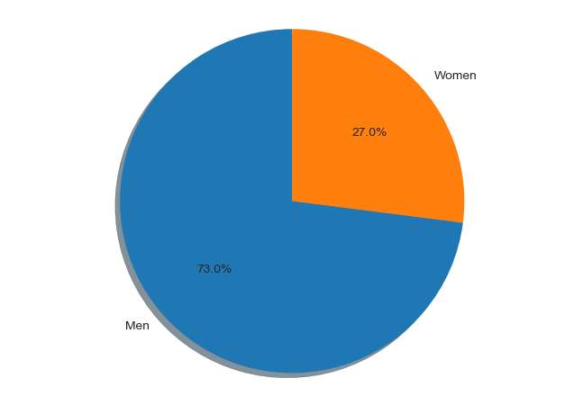

```python
"""
===============
Basic pie chart
===============

Demo of a basic pie chart plus a few additional features.

In addition to the basic pie chart, this demo shows a few optional features:

    * slice labels
    * auto-labeling the percentage
    * offsetting a slice with "explode"
    * drop-shadow
    * custom start angle

Note about the custom start angle:

The default ``startangle`` is 0, which would start the "Frogs" slice on the
positive x-axis. This example sets ``startangle = 90`` such that everything is
rotated counter-clockwise by 90 degrees, and the frog slice starts on the
positive y-axis.
"""
import matplotlib.pyplot as plt

# Pie chart, where the slices will be ordered and plotted counter-clockwise:
labels = dict_keys
sizes = dictvalsvalues
#explode = (0, 0.1, 0, 0)  # only "explode" the 2nd slice (i.e. 'Hogs')

fig1, ax1 = plt.subplots()
ax1.pie(sizes, labels=labels, autopct='%1.1f%%',
        shadow=True, startangle=90)
ax1.axis('equal')  # Equal aspect ratio ensures that pie is drawn as a circle.

plt.show()
```

Observations

- In Olympic games about **73% males and 27% females** participants were involved
- The rate of participation of women in the Olympics has been increasing since their first participation in 1900. Some sports are uniquely for women, other are contested by both sexes, while some older sports remain for men only. Studies of media coverage of the Olympics consistently show differences in the ways in which women and men are described and the ways in which their performances are discussed. **The representation of women on the International Olympic Committee has run well behind the rate of female participation, and it continues to miss its target of a 20% minimum presence of women on their committee**.
- In 1904, **women's golf and tennis were removed** from the programme. The only women's event was **archery**, with only American athletes. Six female athletes competed in St. Louis, 16 fewer than the 1900 games. London 1908 had 37 female athletes who competed in archery, tennis and figure skating. **Stockholm 1912 featured 47 women and saw the addition of swimming and diving, as well as the removal of figure skating and archery.** The 1916 Summer Games were due to be held in Berlin but were cancelled due to the outbreak of World War.

Source : https://en.wikipedia.org/wiki/Participation_of_women_in_the_Olympics

### 4.3. Medal count for Men and Women participants across countries?

- Using groupby function

```python
olympics_data_clean.groupby(['Gender','Medal']).size()
genderwisemedaltally = olympics_data_clean.groupby(['Medal','Gender']).size()
medalwisemedaltally = olympics_data_clean.groupby(['Medal','Gender']).size()

 #genders
#dir(genders)
#dictvals = dict(genderwisemedaltally)
#keys = genderwisemedaltally.keys()
#ict_keys = dictvals.keys()
#dictvalsvalues = dictvals.values()
#dictvalsvalues
#dictvals.values()
medalwisemedaltally
```

```
Medal   Gender
Bronze  Men       7539
        Women     2830
Gold    Men       7698
        Women     2788
Silver  Men       7509
        Women     2801
dtype: int64
```

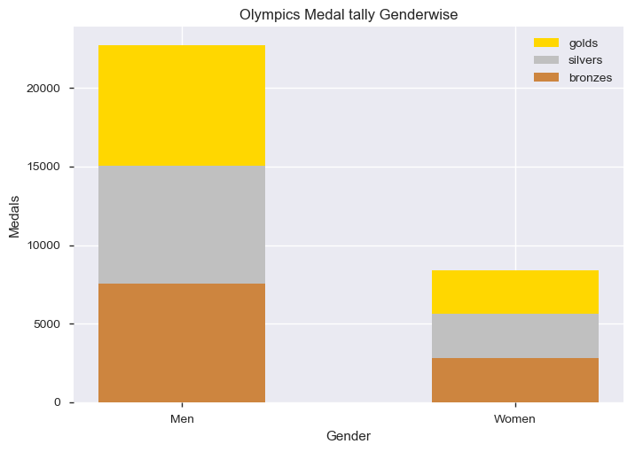

```python
#import pandas as pd
#df=genderwisemedaltally
#df.plot(kind='bar', stacked=True)

gender = ['Men', 'Women']
bronzes = np.array([7539, 2830])
silvers = np.array([7509, 2801])
golds = np.array([7698, 2788])
ind = [x for x, _ in enumerate(gender)]

plt.bar(ind, golds, width=0.5, label='golds', color='gold', bottom=silvers+bronzes)
plt.bar(ind, silvers, width=0.5, label='silvers', color='silver', bottom=bronzes)
plt.bar(ind, bronzes, width=0.5, label='bronzes', color='#CD853F')

plt.xticks(ind, gender)
plt.ylabel("Medals")
plt.xlabel("Gender")
plt.legend(loc="upper right")
plt.title("Olympics Medal tally Genderwise")

plt.show()
```

1. **Mens** have *maximum* number of **Gold Medals** followed by Bronze and Silver
2. **Womens** have *maximum* number of **Bronze Medals** followed by Silver and Gold

### 4.4 Sportswise top performing nations?

```python
#olympics_data_clean.groupby(['Gender','Country']).size()
Sports = olympics_data_clean.groupby(['Sport']).size().sort_values(ascending=False).head(10)


dictvalsSports = dict(Sports)
keysSports = dictvalsSports.keys()
dict_keysSports = dictvalsSports.keys()
dictSportsvalsvalues = dictvalsSports.values()
dictSportsvalsvalues
```

[output not shown]

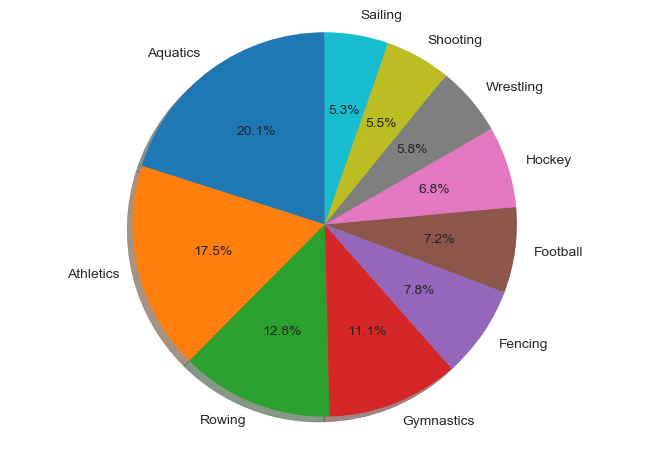

```python
"""
===============
Basic pie chart
===============

Demo of a basic pie chart plus a few additional features.

In addition to the basic pie chart, this demo shows a few optional features:

    * slice labels
    * auto-labeling the percentage
    * offsetting a slice with "explode"
    * drop-shadow
    * custom start angle

Note about the custom start angle:

The default ``startangle`` is 0, which would start the "Frogs" slice on the
positive x-axis. This example sets ``startangle = 90`` such that everything is
rotated counter-clockwise by 90 degrees, and the frog slice starts on the
positive y-axis.
"""
import matplotlib.pyplot as plt

# Pie chart, where the slices will be ordered and plotted counter-clockwise:
labels = dict_keysSports
sizes = dictSportsvalsvalues
#explode = (0, 0.1, 0, 0)  # only "explode" the 2nd slice (i.e. 'Hogs')

fig1, ax1 = plt.subplots()
ax1.pie(sizes, labels=labels, autopct='%1.1f%%',
        shadow=True, startangle=90)
ax1.axis('equal')  # Equal aspect ratio ensures that pie is drawn as a circle.

plt.show()
```

Observations:

1. Athletics,Rowing,Aquatics are top 3 sports played, it covers about 50.4 % of overall sports event

```python
#olympics_data_clean.groupby(['Gender','Country']).size()
Sports = olympics_data_clean.groupby(['Sport','Country']).size().sort_values(ascending=False).head(10)


dictvalsSports = dict(Sports)
keysSports = dictvalsSports.keys()
dict_keysSports = dictvalsSports.keys()
dict_keysSports
#dictSportsvalsvalues = dictvalsSports.values()
#dictSportsvalsvalues
```

[output not shown]

```python
summer = olympics_data_clean.groupby(["Country", "Year"])["Medal"].count().unstack()
summer.head()
countries = [
    "USA", # United States of America
    "CHN", # China
    "RU1", "URS", "EUN", "RUS", # Russian Empire, USSR, Unified Team (post-Soviet collapse), Russia
    "GDR", "FRG", "EUA", "GER", # East Germany, West Germany, Unified Team of Germany, Germany
    "GBR", "AUS", "ANZ", # Australia, Australasia (includes New Zealand)
    "FRA", # France
    "ITA", # Italy,
    "IND" # India
]

sm = summer.loc[countries]
sm.loc["Rest of world"] = summer.loc[summer.index.difference(countries)].sum()
sm = sm[::-1]

country_colors = {
    "USA":"steelblue",
    "CHN":"sandybrown",
    "RU1":"lightcoral", "URS":"indianred", "EUN":"indianred", "RUS":"lightcoral",
    "GDR":"yellowgreen", "FRG":"y",  "EUA":"y", "GER":"y",
    "GBR":"silver",
    "AUS":"darkorchid", "ANZ":"darkorchid",
    "FRA":"silver",
    "ITA":"silver",
    "IND":"blue",
    "Rest of world": "gainsboro"}
```

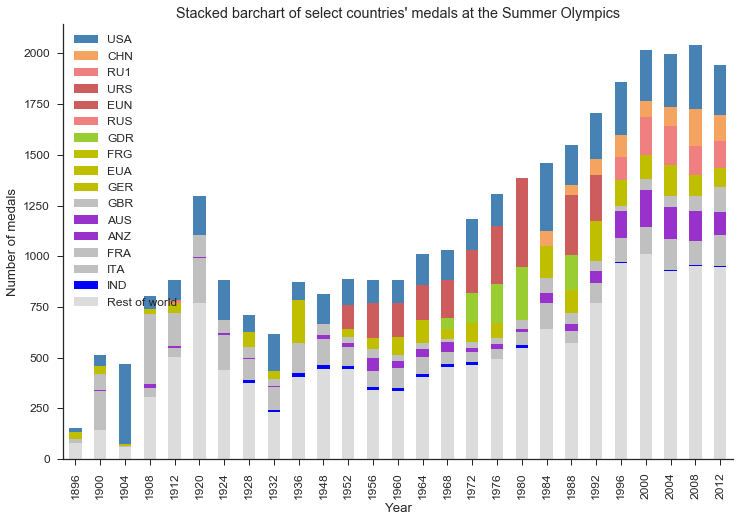

```python
%matplotlib inline

import matplotlib.pyplot as plt
import seaborn as sns
import numpy as np

sns.set_style("ticks")
sns.set_context("notebook", font_scale=1.2)

colors = [country_colors[c] for c in sm.index]

plt.figure(figsize=(12,8))
sm.T.plot.bar(stacked=True, color=colors, ax=plt.gca())

# Reverse the order of labels, so they match the data
handles, labels = plt.gca().get_legend_handles_labels()
plt.legend(handles[::-1], labels[::-1])

# Set labels and remove superfluous plot elements
plt.ylabel("Number of medals")
plt.title("Stacked barchart of select countries' medals at the Summer Olympics")
sns.despine()
```

### 4.5. Global events and their Impact on India's performance in Olympics.

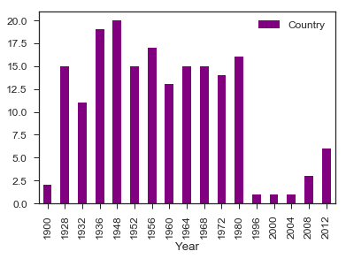

```python
summer = olympics_data_clean
df = pd.DataFrame(summer)
df = pd.DataFrame(summer, columns = ['Year','Country'])
Overallmedals = df.loc[df['Country'] == 'IND'].groupby('Year').count().sum()
Overallmedals
yearwisemedals = df.loc[df['Country'] == 'IND'].groupby('Year').count()
yearwisemedals.plot.bar(stacked=True, color='purple', ax=plt.gca())
```

Observations:

  ```
    Major Reasons:
   - fixed annual budget
   - facilities available to players
   - Only Cricket was given more Importance
   - Major involvement of Politics and Corruption
   Other Reason might be:
   - 1996 Elections in India
   - 1999 Kargil War
   - 2000 Tension on borders with Pakistan, 2001 - Attack on Indian Parliment
   - 2004 Elections in India
   - 2008 Elections in India , Mumbai Attacks
  ```

### 4.6. Most consistent Atheletes in Olympics.

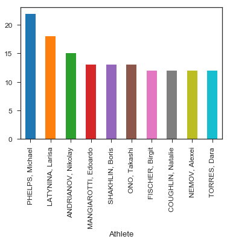

```python
summer = olympics_data_clean
df = pd.DataFrame(summer)
df = pd.DataFrame(summer, columns = ['Athlete','Country','Medal']).groupby(['Athlete']).size().sort_values(ascending=False).head(10)

df.plot.bar(stacked=True)
```

```python
df
```

```
Athlete
PHELPS, Michael         22
LATYNINA, Larisa        18
ANDRIANOV, Nikolay      15
MANGIAROTTI, Edoardo    13
SHAKHLIN, Boris         13
ONO, Takashi            13
FISCHER, Birgit         12
COUGHLIN, Natalie       12
NEMOV, Alexei           12
TORRES, Dara            12
dtype: int64
```

Observation

- Michael PHELPS from USA tops the Overall consistent performer in Olympics
- Larisa LATYNINA from Russia in second spot in the Overall consistent performer in Olympics
- Nikolay ANDRIANOV from Russia in third spot in the Overall consistent performer in Olympics

### 4.7 Hypothesis: Olympic games are dominated by male athletes and athletes from developed countries performed better than underdeveloped countries .

On studying Questionnaire 4.1 we observed that Athletes from developed countries performed better than underdeveloped countries.

On studying Questionnaire 4.2 we observed that Olympic games are dominated by Male Athletes, Male won of 73% and Female won 27% of medals.

India's performance after 1980 gone down due to several factors affecting the growth of the Athletes

## 5. Conclusion

- With this project we learnt how explore the data and performed the analysis using Pandas and Numpy packages.
- Also we have seen making use of packages like **matplotlib, seaborn** and **plotly** to develop better insights about the data.
- We also make use of **pandas profiling** feature to generate an html report containing all the information of the various features present in the dataset.
- This analysis will help us to choose which **machine learning model** we can apply to draw future pattern of Olympics and try to incorporate the insight to improve the sports, to formulate more Athlete friendly policies.

back to Index